# Ass 1

========================================================================================================

### Loading and preprocessing the data

To load the data i just used the code below. The dataset “dataperyear” has the aggregated data per date

```r
data<-read.csv("activity.csv")
dataperyear<- aggregate(data$steps,by=data["date"],FUN=sum, na.rm=TRUE)
```

### What is mean total number of steps taken per day?

**Make a histogram of the total number of steps taken each day**

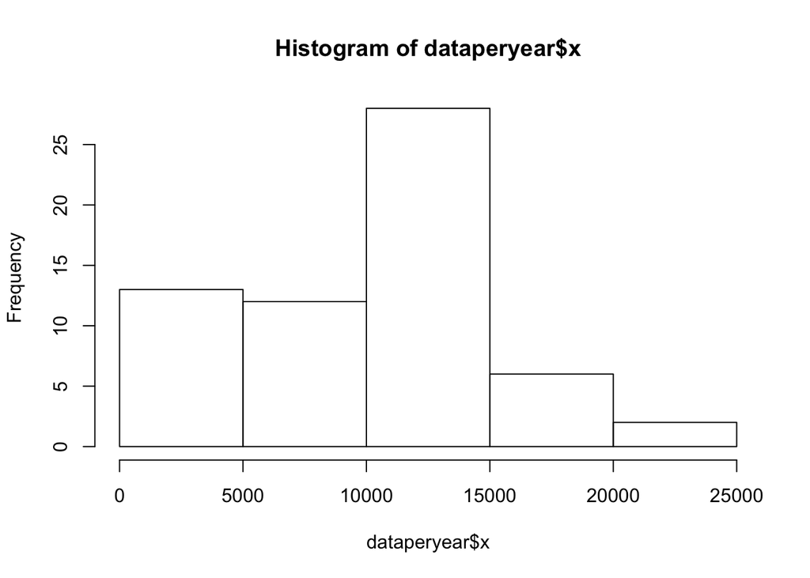

```r
hist(dataperyear$x)
```

```r
mean<- aggregate(data$steps,by=data["date"],FUN=mean, na.rm=TRUE)

median<- aggregate(data$steps,by=data["date"],FUN=median, na.rm=TRUE)
```

### What is the average daily activity pattern?

**Make a time series plot (i.e. type = “l”) of the 5-minute interval (x-axis) and the average number of steps taken, averaged across all days (y-axis)**

```r
mean2<- aggregate(data$steps,by=data["interval"],FUN=mean, na.rm=TRUE)
```

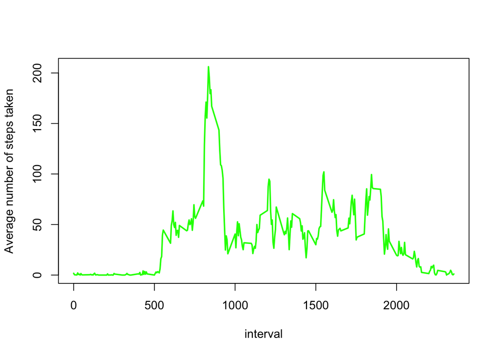

```r
plot(mean2$interval, mean2$x, type="l", xlab= "interval", ylab= "Average number of steps taken", col="green" , lwd=2)
```

**Which 5-minute interval, on average across all the days in the dataset, contains the maximum number of steps?**

```r
which.max(mean2$x)

s<-mean2[which.max(mean2$x),1]
```

[output not shown]

### Imputing missing values

**Calculate and report the total number of missing values in the dataset (i.e. the total number of rows with NAs)**

```r
library(plyr)
ddply(data,.(date), summarise, Count_Missing= sum(is.na(steps)), Count_No_Missing= sum(!is.na(steps)))
```

```
##          date Count_Missing Count_No_Missing
## 1  2012-10-01           288                0
## 2  2012-10-02             0              288
## 3  2012-10-03             0              288
## 4  2012-10-04             0              288
## 5  2012-10-05             0              288
## 6  2012-10-06             0              288
## 7  2012-10-07             0              288
## 8  2012-10-08           288                0
## 9  2012-10-09             0              288
## 10 2012-10-10             0              288
## 11 2012-10-11             0              288
## 12 2012-10-12             0              288
## 13 2012-10-13             0              288
## 14 2012-10-14             0              288
```

[output cut: 47 more lines]

**Devise a strategy for filling in all of the missing values in the dataset. The strategy does not need to be sophisticated. For example, you could use the mean/median for that day, or the mean for that 5-minute interval, etc.**

In this case i used the mean of 5-minute interval. Firstly i create a function which replace with the mean. Then i used the function ddply. The code is the below

```r
impute.mean <- function(x) replace(x, is.na(x), mean(x, na.rm = TRUE))


#transform the data
data_trans<-ddply(data,.(interval), transform, steps= impute.mean(steps))

data_trans[order(data_trans$date), ] #plyr orders by group so we have to reorder

#onvert do date
data_trans$date<-as.Date(data_trans$date)


#create list with weekends

weekend<-c("Saturday", "Sunday")

#create one more column with weekdays

data_trans$weekday <- weekdays(data_trans$date, abbreviate=FALSE)

#create one more column with TRUE, FALSE regarding whether is weekend


data_trans$IsWeekend <- data_trans$weekday %in% weekend
```

The plot is the following

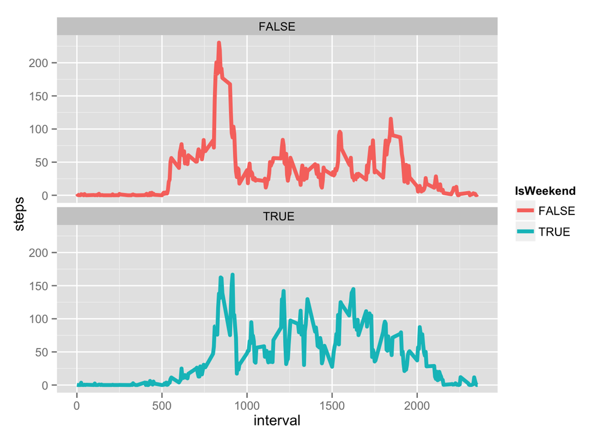

```r
#take the average per interval and per whether is weekend


mean3<- aggregate(data_trans$steps,by=list(data_trans$interval, data_trans$IsWeekend),FUN=mean, na.rm=TRUE)

#rename the column names
colnames(mean3)<-c("interval", "IsWeekend", "steps")
library(ggplot2)
p<-ggplot(mean3, aes(x=interval,y=steps))+geom_line(aes(color=IsWeekend),size=1.5)+facet_wrap(~IsWeekend, nrow=2)

print(p)
```